# introduction_deep_learning slides

[figure not shown]

## Machine Learning Basics

### Classification

```python
positives = np.array([[0.4, 0.4], [0, 0.6], [0.2, 0.6], [0.1, 0.3]])
negatives = np.array([[0.2, 0], [0.6, 0.4], [0.5, 0.2]])
data = np.concatenate([positives, negatives])
labels = np.array([1, 1, 1, 1, 0, 0, 0])
```

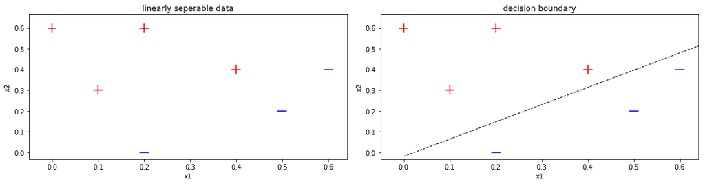

```python
plot_data1(data, labels)
```

#### How to classify (put a decision boundary) linearly seperable data?

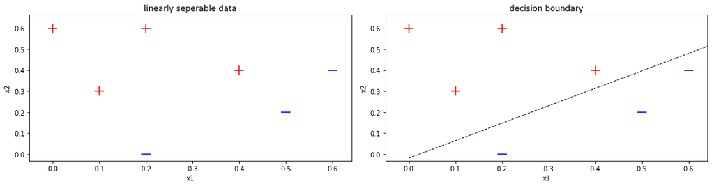

```python
plot_data1(data, labels)
```

Natural Attempt to find a decision boundary:  
$f_w(x) = w_1x1 + w_2x2 + w_0 = W^TX$  
$W^TX = 0$ is a line called decision boundary  
$y = 1$ if $W^TX > 0$  
$y = 0$ if $W^TX < 0$

#### How to find proper weights that seperates the data well?

- We need a loss function that tells how bad we are at classification.
- Our purpose is to find the best weights that minimizes the loss.

Example Loss Function:

Find $W$ that minimizes $\hat{L}(f_w)=\dfrac{1}{n}\sum_{i=1}^{n} (\hat{y_i}-y_i)^2$ where $\hat{y_i}$ is prediction value, $y_i$ is the actual value.

#### We want our prediction to be either 0 or 1, but $W^TX$ can take any value

### Sigmoid Function:

$\sigma{(z)} = \dfrac{1}{1+exp(-z)}$

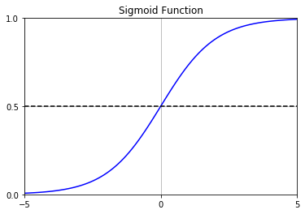

```python
plotsigmoid()
```

Find $w$ that minimizes $\hat{L}(f_w)=\dfrac{1}{n}\sum_{i=1}^{n} (\sigma(w^Tx_i)-y_i)^2$

#### How to update weights to decrease our cost function?

#### Gradient Descent

Minimize loss $\hat{L}(W)$, where the hypothesis is parametrized by $W$

- Initialize $W_0$
- $W_{t+1} = W_t - \eta_t\nabla\hat{L}(W_t)$

#### Different Gradient Descent Implementations

[figure not shown]

#### How can we implement this without taking the all ugly derivations?

- Keras: The Python Deep Learning library
- Works on top of Tensorflow
- Does all the ugly work for us :)

```python
from keras.models import Sequential
from keras.layers import Dense, Activation

model = Sequential()
model.add(Dense(1, input_shape=(2,), activation='sigmoid'))

batch_size = 1
np_epoch = 100

model.compile(optimizer='adam', loss='mse', metrics=['accuracy'])

history = model.fit(data, labels, batch_size, np_epoch)
```

#### What Keras provides us as history?

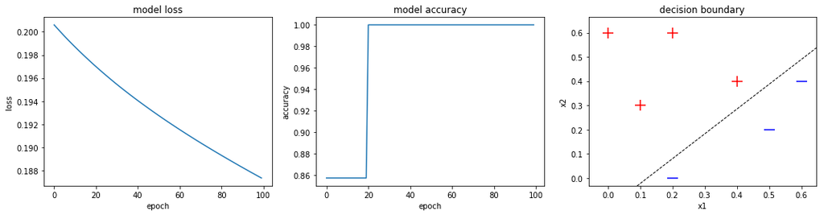

```python
drawlogisticplots()
```

#### What if our problem is not linearly seperable?

##### XOR Problem

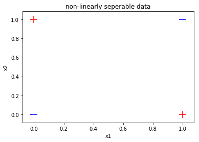

```python
positives = np.array([[1, 0], [0, 1]])
negatives = np.array([[0, 0], [1, 1]])

data = np.concatenate([positives, negatives])
labels = np.array([1, 1, 0, 0])
plot_data2(data, labels)
```

##### We need a classifier for non-linearly seperable data.

## Neural Networks

[figure not shown]

##### Weights and input values are multiplied again

$h(x)=W_1^Tx$  
$g(h)=W_2^Th$  
$f(x)=g(h(x))$

##### We need non-linear activation functions such as sigmoid, tanh and ReLu

### Nonlinear Activation Functions

#### Sigmoid Function

$\sigma{(z)} = \dfrac{1}{1+e^{-z}}$

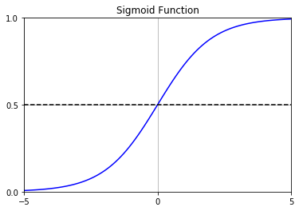

```python
plotsigmoid()
```

#### Tanh

$tanh(z) = \dfrac{e^z-e^{-z}}{e^z+e^{-z}}$

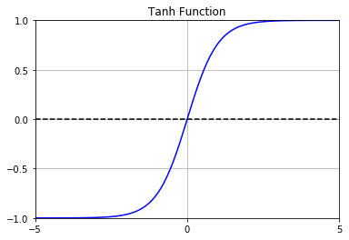

```python
plottanh()
```

#### ReLu (Rectified Linear Unit)

$relu(z) = max(0, z)$

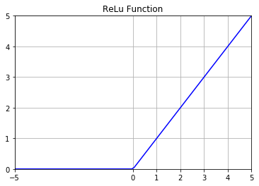

```python
plotrelu()
```

- Neural network learns by minimizing the cost function $\hat{L}(f_w)=\dfrac{1}{n}\sum_{i=1}^{n} (\hat{y_i}-y_i)^2$

#### How weights are updated for neural networks?

##### Backpropagation

- Repeated application of chain rule for partial derivatives. Finds the gradient of the loss $\hat{L}$ w.r.t. all parameters of neural network.
- Thanks to Keras we don't need to take derivatives again :)

### Solving XOR problem with multi layer neural network

```python
from keras.models import Sequential
from keras.layers import Dense, Activation

model = Sequential()
model.add(Dense(20, input_shape=(2,), activation='relu'))
model.add(Dense(1, activation='sigmoid'))

batch_size = 1
np_epoch = 200

model.compile(optimizer='adam', loss='mse', metrics=['accuracy'])

history = model.fit(data, labels, batch_size, np_epoch)
```

```python
def plotxor():
    plt.figure(figsize=(15, 4))
    ax1 = plt.subplot(1,3,1)
    ax1.plot(history.history['loss'])
    ax1.set_title('model loss')
    ax1.set_ylabel('loss')
    ax1.set_xlabel('epoch')
    ax2 = plt.subplot(1,3,2)
    ax2.plot(history.history['acc'])
    ax2.set_title('model accuracy')
    ax2.set_ylabel('accuracy')
    ax2.set_xlabel('epoch')
    ax3 = plt.subplot(1,3,3)
    ax3.scatter(positives[:, 0], positives[:, 1],
                           color='red', marker='+', s=200)
    ax3.scatter(negatives[:, 0], negatives[:, 1],
                           color='blue', marker='_', s=200)
    x1_min, x1_max = data[:, 0].min() - 1, data[:, 0].max() + 1
    x2_min, x2_max = data[:, 1].min() -1 , data[:, 1].max() + 1
    xx1, xx2 = np.meshgrid(np.arange(x1_min, x1_max, 0.02),
                         np.arange(x2_min, x2_max, 0.02))
    Z = np.array(model.predict_classes(np.c_[xx1.ravel(), xx2.ravel()]))
    Z = Z.reshape(xx1.shape)
    #ax3.scatter(data[:, 0], data[:, 1], c=labels, alpha=0.1)
    ax3.contourf(xx1, xx2, Z, alpha=0.4, cmap=plt.cm.coolwarm, s=20, edgecolors='k')
    ax3.set_xlabel('x1')
    ax3.set_ylabel('x2')
    ax3.set_title('decision boundary')
    plt.tight_layout()
    plt.show()
```

#### Plotting the Keras history

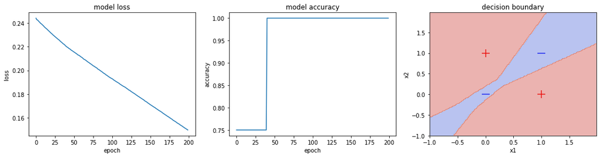

```python
plotxor()
```

#### What if the problem is too difficult to solve?

##### Deep Neural Networks

- A deep network can represent very complex functions
- It needs large labeled dataset
- CPUs are too slow GPUs are usually needed
- Regularization is necessary to prevent overfitting
- Domain specific arhitectures are needed such as Convolution Neural Net, Recurrent Neural net and so on

#### Example Architecture Convolutional Neural Net

- Mostly used in image classfications
- Instead of fully connected layers it uses convolution filters
- Benefits mostly from Large Scale Visual Recognition Challenge dataset ImageNet

| Convolution Layer | Pooling Layer |
| --- | --- |

#### What if we don't have enough computing resources? Should we give up Deep Learning?

##### Transfer Learning on Convolutional Neural Network

- We use pretrained models (weights are already updated) to perform classfication.
- If the dataset which is trained on the model, different than our dataset, we can still benefit the weights.

##### Image classfication on CIFAR-10 dataset using transfer learning

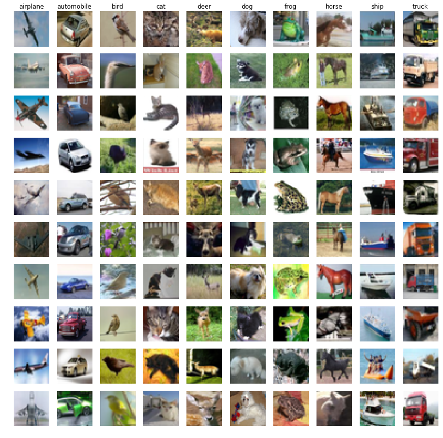

```python
plotcifar10()
```

##### We will use a pretrained model from Keras to extract features

```python
from keras.applications import resnet50
from keras.preprocessing.image import ImageDataGenerator
from keras.preprocessing.image import array_to_img, img_to_array
model = resnet50.ResNet50(weights='imagenet', include_top=False, input_shape=(224, 224, 3))
```

```python
def extract_features(images, model, preprocessing_function, hw_tuple=(224,224)):
    features = []
    for image in tqdm(images):
        img = array_to_img(image)
        img = img.resize(hw_tuple)
        m = img_to_array(img)
        t = np.expand_dims(m, axis=0)
        x = preprocessing_function(t)
        p = model.predict(x)
        features.extend(p)
    return features
```

```python
# train features
bottleneck_features_train = extract_features(X_train, model, resnet50.preprocess_input)
```

#### Small Fully Connected Network for Classification using bottlenect features

```python
from keras.layers import Flatten, Dropout

model = Sequential()
model.add(Flatten(input_shape=bottleneck_features_train.shape[1:]))
model.add(Dense(256, activation='relu'))
model.add(Dropout(0.5))
model.add(Dense(10, activation='softmax'))

model.compile(optimizer='adam',
              loss='sparse_categorical_crossentropy',
              metrics=['accuracy'])
```

```python
history = model.fit(bottleneck_features_train, y_train, validation_split=0.2)
```

```
Train on 800 samples, validate on 200 samples
```

##### Plotting the Keras history for the classification

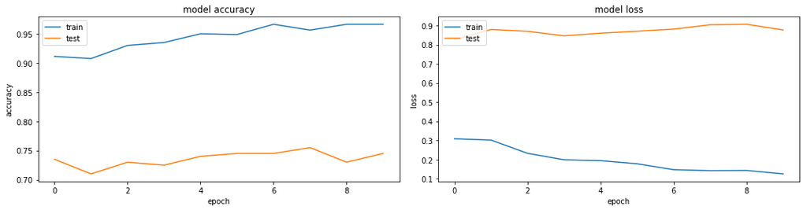

```python
plotsmallnetwork()
```

```python
y_pred = model.predict_classes(bottleneck_features_test)
```

##### How good our new model is with the test data?

```python
from sklearn.metrics import accuracy_score
from sklearn.metrics import classification_report

print ("Accuracy Score: ", accuracy_score(y_test, y_pred))
print (classification_report(y_test, y_pred, target_names=label_names))
```

```
Accuracy Score:  0.7
             precision    recall  f1-score   support

   airplane       0.60      0.60      0.60        20
 automobile       0.72      0.93      0.81        14
       bird       0.62      0.48      0.54        21
        cat       0.71      0.79      0.75        19
       deer       0.46      0.40      0.43        15
        dog       0.58      0.61      0.59        18
       frog       0.77      0.77      0.77        26
      horse       0.62      0.72      0.67        18
       ship       0.92      0.79      0.85        28
      truck       0.82      0.86      0.84        21

avg / total       0.70      0.70      0.70       200
```